# Correlation comparison

Byron Jaeger

March 17, 2019

## This document

The purpose of this document is to illustrate the method I have applied to compare the associations between left ventricular hypertropy and nocturnal hypertension when (1) a full set of $\geq 5$ blood pressure measurements are used to estimate mean blood pressure during sleep, and (2) a set of $<$ 5 blood pressure measurements are used to estimate mean blood pressure during sleep.

### Part 1

Set a couple of control variables for poisson regression models:

Import a dataset with information on left-ventricular hypertrophy status and mean blood pressure during sleep according to a full set of $\geq 5$ blood pressure measurements.

```
## # A tibble: 773 x 14
##    subjid   lvm   lvh   acr albuminuria slp_sbp slp_dbp   age sex   edu
##    <chr>  <dbl> <dbl> <dbl>       <dbl>   <dbl>   <dbl> <dbl> <chr> <chr>
##  1 J1000~  80.7     0 NA             NA    117.    62.3  62.1 Fema~ Less~
##  2 J1001~  69.6     0 NA             NA    112.    55.7  75.2 Fema~ Atte~
##  3 J1003~  82.1     0 14.9            0    132.    80.5  77   Male  Atte~
##  4 J1005~ 137.      1 NA             NA    114     61.5  72.6 Fema~ Less~
##  5 J1007~  92.0     0 NA             NA    123.    58.2  77.5 Fema~ Less~
##  6 J1011~  63.1     0 NA             NA    111.    62.4  65.3 Fema~ High~
##  7 J1018~ 113.      1 NA             NA    151.    76.7  63.2 Fema~ Atte~
##  8 J1025~  58.0     0  4.54           0    115.    59.8  69.8 Fema~ Less~
##  9 J1026~  85.9     0  4.14           0    118.    65.7  69.2 Fema~ High~
## 10 J1033~  87.2     0 NA             NA    121.    67.0  70.4 Fema~ Less~
## # ... with 763 more rows, and 4 more variables: diabetes <chr>,
## #   currentsmoker <chr>, bpmeds <chr>, slp_duration <dbl>
```

Import a dataset that contains blood pressure measurements taken at 1, 2, 3, and 4 AM from participants in the Jackson Heart Study.

```
## # A tibble: 3,092 x 4
## # Groups:   subjid [773]
##    subjid    tsm   sbp   dbp
##    <chr>   <dbl> <dbl> <dbl>
##  1 J100079  1.05    92    44
##  2 J100079  2.05   117    62
##  3 J100079  3.05   112    62
##  4 J100079  4.05   114    65
##  5 J100180  1      102    47
##  6 J100180  1.95    99    42
##  7 J100180  2.95   123    59
##  8 J100180  3.95   118    59
##  9 J100333  1.47   131    82
## 10 J100333  2.13   142    87
## # ... with 3,082 more rows
```

```
## # A tibble: 572 x 16
##    subjid slp_sbp_est slp_dbp_est   lvm   lvh   acr albuminuria slp_sbp
##    <chr>        <dbl>       <dbl> <dbl> <dbl> <dbl>       <dbl>   <dbl>
##  1 J1003~        135.        86.8  82.1     0 14.9            0    132.
##  2 J1025~        112.        56.8  58.0     0  4.54           0    115.
##  3 J1026~        117         65.2  85.9     0  4.14           0    118.
##  4 J1034~        120.        78.5  72.2     0  4.75           0    126.
##  5 J1041~        134.        64    70.1     0 62.4            1    132.
##  6 J1049~        102         58.8  89.2     0  4.58           0    103.
##  7 J1056~        119.        67.8  71.9     0 51.8            1    122.
##  8 J1061~        132.        76.5  81.4     0  4.38           0    140.
##  9 J1066~        119.        52.2  91.9     0  4.31           0    121.
## 10 J1066~        140.        84.5  90.1     0  4.53           0    145.
## # ... with 562 more rows, and 8 more variables: slp_dbp <dbl>, age <dbl>,
## #   sex <chr>, edu <chr>, diabetes <chr>, currentsmoker <chr>,
## #   bpmeds <chr>, slp_duration <dbl>
```

As a quick tangent, note the correlation between estimated nocturnal SBP and SBP and true nocturnal SBP and DBP

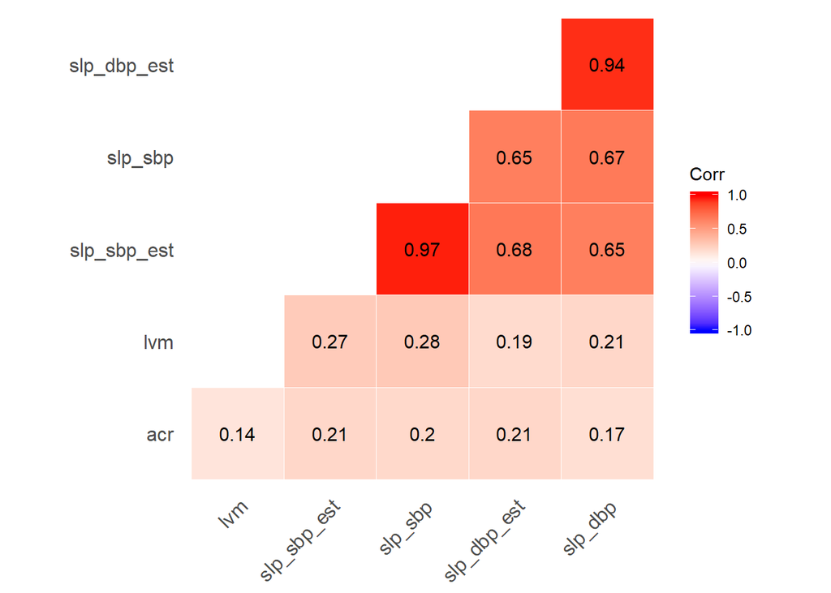

### Part 2

Fit regression models for LVH

```
## # A tibble: 2 x 9
##   model term      estimate std.error statistic p.value pr_est pr_lwr pr_upr
##   <chr> <chr>        <dbl>     <dbl>     <dbl>   <dbl>  <dbl>  <dbl>  <dbl>
## 1 1     slp_sbp      0.307     0.130      5.63 0.0177    1.36   1.05   1.75
## 2 2     slp_sbp_~    0.316     0.114      7.64 0.00572   1.37   1.10   1.72
```

The effects appear to be almost identical. Here is the same analysis, using albuminuria

```
## # A tibble: 2 x 9
##   model term      estimate std.error statistic p.value pr_est pr_lwr pr_upr
##   <chr> <chr>        <dbl>     <dbl>     <dbl>   <dbl>  <dbl>  <dbl>  <dbl>
## 1 1     slp_sbp      0.316    0.0952      11.1 8.83e-4   1.37   1.14   1.65
## 2 2     slp_sbp_~    0.299    0.0907      10.8 9.97e-4   1.35   1.13   1.61
```

## Part 3

Bootstrap the difference in prevalence ratios. The code is omitted because it is just a loop of the code above.

Bias corrected accelerated (BCA) and standard bootstrap distributions for the difference in association with left-ventricular hypertrophy between estimated and true nocturnal systolic blood pressure.

| BCA | BCA percentile | standard | standard percentile |
| --- | --- | --- | --- |
| -0.007 | 0.025 | -0.007 | 0.018 |
| -0.006 | 0.05 | -0.006 | 0.036 |
| -0.005 | 0.1 | -0.005 | 0.076 |
| -0.005 | 0.16 | -0.005 | 0.127 |
| -0.002 | 0.5 | -0.002 | 0.442 |
| 0.000 | 0.84 | 0.001 | 0.802 |
| 0.001 | 0.9 | 0.001 | 0.871 |
| 0.002 | 0.95 | 0.002 | 0.933 |
| 0.004 | 0.975 | 0.003 | 0.964 |

Bias corrected accelerated (BCA) and standard bootstrap distributions for the difference in association with albuminuria between estimated and true nocturnal systolic blood pressure.

| BCA | BCA percentile | standard | standard percentile |
| --- | --- | --- | --- |
| -0.008 | 0.025 | -0.008 | 0.033 |
| -0.007 | 0.05 | -0.008 | 0.064 |
| -0.007 | 0.1 | -0.007 | 0.124 |
| -0.006 | 0.16 | -0.006 | 0.193 |
| -0.004 | 0.5 | -0.005 | 0.547 |
| -0.003 | 0.84 | -0.003 | 0.869 |
| -0.002 | 0.9 | -0.002 | 0.920 |
| -0.001 | 0.95 | -0.001 | 0.962 |
| -0.001 | 0.975 | -0.001 | 0.982 |